# Moneyball

Justine

8/11/2020

## Exploratory Data Analysis

Data from [Sean Lahaman’s Website](http://www.seanlahman.com/baseball-archive/statistics/).

```r
library(readxl)
#batting file
batting <- read.csv('Batting.csv')
head(batting) #check first rows
```

playerID yearID stint teamID lgID G G_batting AB R H X2B X3B HR RBI SB CS 1 aardsda01 2004 1 SFN NL 11 11 0 0 0 0 0 0 0 0 0 2 aardsda01 2006 1 CHN NL 45 43 2 0 0 0 0 0 0 0 0 3 aardsda01 2007 1 CHA AL 25 2 0 0 0 0 0 0 0 0 0 4 aardsda01 2008 1 BOS AL 47 5 1 0 0 0 0 0 0 0 0 5 aardsda01 2009 1 SEA AL 73 3 0 0 0 0 0 0 0 0 0 6 aardsda01 2010 1 SEA AL 53 4 0 0 0 0 0 0 0 0 0 BB SO IBB HBP SH SF GIDP G_old 1 0 0 0 0 0 0 0 11 2 0 0 0 0 1 0 0 45 3 0 0 0 0 0 0 0 2 4 0 1 0 0 0 0 0 5 5 0 0 0 0 0 0 0 NA 6 0 0 0 0 0 0 0 NA

```r
str(batting) #check structure
```

‘data.frame’: 97889 obs. of 24 variables: $ playerID : Factor w/ 18107 levels “aardsda01”,“aaronha01”,..: 1 1 1 1 1 1 1 2 2 2 … $ yearID : int 2004 2006 2007 2008 2009 2010 2012 1954 1955 1956 … $ stint : int 1 1 1 1 1 1 1 1 1 1 … $ teamID : Factor w/ 149 levels “ALT”,“ANA”,“ARI”,..: 117 35 33 16 116 116 93 80 80 80 … $ lgID : Factor w/ 6 levels “AA”,“AL”,“FL”,..: 4 4 2 2 2 2 2 4 4 4 … $ G : int 11 45 25 47 73 53 1 122 153 153 … $ G_batting: int 11 43 2 5 3 4 NA 122 153 153 … $ AB : int 0 2 0 1 0 0 NA 468 602 609 … $ R : int 0 0 0 0 0 0 NA 58 105 106 … $ H : int 0 0 0 0 0 0 NA 131 189 200 … $ X2B : int 0 0 0 0 0 0 NA 27 37 34 … $ X3B : int 0 0 0 0 0 0 NA 6 9 14 … $ HR : int 0 0 0 0 0 0 NA 13 27 26 … $ RBI : int 0 0 0 0 0 0 NA 69 106 92 … $ SB : int 0 0 0 0 0 0 NA 2 3 2 … $ CS : int 0 0 0 0 0 0 NA 2 1 4 … $ BB : int 0 0 0 0 0 0 NA 28 49 37 … $ SO : int 0 0 0 1 0 0 NA 39 61 54 … $ IBB : int 0 0 0 0 0 0 NA NA 5 6 … $ HBP : int 0 0 0 0 0 0 NA 3 3 2 … $ SH : int 0 1 0 0 0 0 NA 6 7 5 … $ SF : int 0 0 0 0 0 0 NA 4 4 7 … $ GIDP : int 0 0 0 0 0 0 NA 13 20 21 … $ G_old : int 11 45 2 5 NA NA NA 122 153 153 …

```r
head(batting$AB) #check first rows of $At Bats
```

[1] 0 2 0 1 0 0

```r
head(batting$X2B) #doubles
```

[1] 0 0 0 0 0 0

## Feature Engineering

Add three more statistics: - Batting Average - On Base Percentage - Slugging Percentage

```r
#Create New Column: Batting Average = Hits/At Bats
batting$BA <- batting$H / batting$AB
tail(batting$BA, 5) #check last entries of Batting Average
```

```
## [1] 0.1230769 0.2746479 0.1470588 0.2745098 0.2138728
```

```r
#new column: On Base Percentage: (Hits+Bases on Balls+Hit By Pitch) / (At Bats+Bases on Balls+Hit By Pitch+Sacrifice Fly)
batting$OBP <- (batting$H+batting$BB+batting$HBP)/(batting$AB+batting$BB+batting$HBP+batting$SF)
#new column: singles = Hits-doubles-triples-homerums
batting$X1B <- (batting$H-batting$X2B-batting$X3B-batting$HR)
head(batting$X1B)
```

```
## [1] 0 0 0 0 0 0
```

```r
#new column: Slugging Percentage:
batting$SLG <- (batting$X1B+2*batting$X2B+3*batting$X3B+4*batting$HR)/batting$AB
head(batting$SLG)
```

```
## [1] NaN   0 NaN   0 NaN NaN
```

```r
str(batting)
```

```
## 'data.frame':    97889 obs. of  28 variables:
##  $ playerID : Factor w/ 18107 levels "aardsda01","aaronha01",..: 1 1 1 1 1 1 1 2 2 2 ...
##  $ yearID   : int  2004 2006 2007 2008 2009 2010 2012 1954 1955 1956 ...
##  $ stint    : int  1 1 1 1 1 1 1 1 1 1 ...
##  $ teamID   : Factor w/ 149 levels "ALT","ANA","ARI",..: 117 35 33 16 116 116 93 80 80 80 ...
##  $ lgID     : Factor w/ 6 levels "AA","AL","FL",..: 4 4 2 2 2 2 2 4 4 4 ...
##  $ G        : int  11 45 25 47 73 53 1 122 153 153 ...
##  $ G_batting: int  11 43 2 5 3 4 NA 122 153 153 ...
##  $ AB       : int  0 2 0 1 0 0 NA 468 602 609 ...
##  $ R        : int  0 0 0 0 0 0 NA 58 105 106 ...
##  $ H        : int  0 0 0 0 0 0 NA 131 189 200 ...
##  $ X2B      : int  0 0 0 0 0 0 NA 27 37 34 ...
##  $ X3B      : int  0 0 0 0 0 0 NA 6 9 14 ...
##  $ HR       : int  0 0 0 0 0 0 NA 13 27 26 ...
##  $ RBI      : int  0 0 0 0 0 0 NA 69 106 92 ...
##  $ SB       : int  0 0 0 0 0 0 NA 2 3 2 ...
##  $ CS       : int  0 0 0 0 0 0 NA 2 1 4 ...
##  $ BB       : int  0 0 0 0 0 0 NA 28 49 37 ...
##  $ SO       : int  0 0 0 1 0 0 NA 39 61 54 ...
##  $ IBB      : int  0 0 0 0 0 0 NA NA 5 6 ...
##  $ HBP      : int  0 0 0 0 0 0 NA 3 3 2 ...
##  $ SH       : int  0 1 0 0 0 0 NA 6 7 5 ...
##  $ SF       : int  0 0 0 0 0 0 NA 4 4 7 ...
##  $ GIDP     : int  0 0 0 0 0 0 NA 13 20 21 ...
##  $ G_old    : int  11 45 2 5 NA NA NA 122 153 153 ...
##  $ BA       : num  NaN 0 NaN 0 NaN ...
##  $ OBP      : num  NaN 0 NaN 0 NaN ...
##  $ X1B      : int  0 0 0 0 0 0 NA 85 116 126 ...
##  $ SLG      : num  NaN 0 NaN 0 NaN ...
```

## Merge Sales Data with Batting Data

To find not only the best players, but also most undervalued players.

```r
sal <- read.csv('Salaries.csv')
summary(batting)
```

```
##       playerID         yearID         stint           teamID        lgID
##  mcguide01:   31   Min.   :1871   Min.   :1.000   CHN    : 4720   AA  : 1890
##  henderi01:   29   1st Qu.:1931   1st Qu.:1.000   PHI    : 4621   AL  :44369
##  newsobo01:   29   Median :1970   Median :1.000   PIT    : 4575   FL  :  470
##  johnto01 :   28   Mean   :1962   Mean   :1.077   SLN    : 4535   NL  :49944
##  kaatji01 :   28   3rd Qu.:1995   3rd Qu.:1.000   CIN    : 4393   PL  :  147
##  ansonca01:   27   Max.   :2013   Max.   :5.000   CLE    : 4318   UA  :  332
##  (Other)  :97717                                  (Other):70727   NA's:  737
##        G            G_batting            AB              R
##  Min.   :  1.00   Min.   :  0.00   Min.   :  0.0   Min.   :  0.00
##  1st Qu.: 13.00   1st Qu.:  7.00   1st Qu.:  9.0   1st Qu.:  0.00
##  Median : 35.00   Median : 32.00   Median : 61.0   Median :  5.00
##  Mean   : 51.65   Mean   : 49.13   Mean   :154.1   Mean   : 20.47
##  3rd Qu.: 81.00   3rd Qu.: 81.00   3rd Qu.:260.0   3rd Qu.: 31.00
##  Max.   :165.00   Max.   :165.00   Max.   :716.0   Max.   :192.00
##                   NA's   :1406     NA's   :6413    NA's   :6413
##        H               X2B            X3B               HR
##  Min.   :  0.00   Min.   : 0.0   Min.   : 0.000   Min.   : 0.000
##  1st Qu.:  1.00   1st Qu.: 0.0   1st Qu.: 0.000   1st Qu.: 0.000
##  Median : 12.00   Median : 2.0   Median : 0.000   Median : 0.000
##  Mean   : 40.37   Mean   : 6.8   Mean   : 1.424   Mean   : 3.002
##  3rd Qu.: 66.00   3rd Qu.:10.0   3rd Qu.: 2.000   3rd Qu.: 3.000
##  Max.   :262.00   Max.   :67.0   Max.   :36.000   Max.   :73.000
##  NA's   :6413     NA's   :6413   NA's   :6413     NA's   :6413
##       RBI               SB                CS               BB
##  Min.   :  0.00   Min.   :  0.000   Min.   : 0.000   Min.   :  0.00
##  1st Qu.:  0.00   1st Qu.:  0.000   1st Qu.: 0.000   1st Qu.:  0.00
##  Median :  5.00   Median :  0.000   Median : 0.000   Median :  4.00
##  Mean   : 18.47   Mean   :  3.265   Mean   : 1.385   Mean   : 14.21
##  3rd Qu.: 28.00   3rd Qu.:  2.000   3rd Qu.: 1.000   3rd Qu.: 21.00
##  Max.   :191.00   Max.   :138.000   Max.   :42.000   Max.   :232.00
##  NA's   :6837     NA's   :7713      NA's   :29867    NA's   :6413
##        SO              IBB              HBP               SH
##  Min.   :  0.00   Min.   :  0.00   Min.   : 0.000   Min.   : 0.000
##  1st Qu.:  2.00   1st Qu.:  0.00   1st Qu.: 0.000   1st Qu.: 0.000
##  Median : 11.00   Median :  0.00   Median : 0.000   Median : 1.000
##  Mean   : 21.95   Mean   :  1.28   Mean   : 1.136   Mean   : 2.564
##  3rd Qu.: 31.00   3rd Qu.:  1.00   3rd Qu.: 1.000   3rd Qu.: 3.000
##  Max.   :223.00   Max.   :120.00   Max.   :51.000   Max.   :67.000
##  NA's   :14251    NA's   :42977    NA's   :9233     NA's   :12751
##        SF             GIDP           G_old              BA
##  Min.   : 0.0    Min.   : 0.00   Min.   :  0.00   Min.   :0.000
##  1st Qu.: 0.0    1st Qu.: 0.00   1st Qu.: 11.00   1st Qu.:0.148
##  Median : 0.0    Median : 1.00   Median : 34.00   Median :0.231
##  Mean   : 1.2    Mean   : 3.33   Mean   : 50.99   Mean   :0.209
##  3rd Qu.: 2.0    3rd Qu.: 5.00   3rd Qu.: 82.00   3rd Qu.:0.275
##  Max.   :19.0    Max.   :36.00   Max.   :165.00   Max.   :1.000
##  NA's   :42446   NA's   :32521   NA's   :5189     NA's   :13520
##       OBP             X1B              SLG
##  Min.   :0.00    Min.   :  0.00   Min.   :0.000
##  1st Qu.:0.19    1st Qu.:  1.00   1st Qu.:0.179
##  Median :0.29    Median :  9.00   Median :0.309
##  Mean   :0.26    Mean   : 29.14   Mean   :0.291
##  3rd Qu.:0.34    3rd Qu.: 48.00   3rd Qu.:0.397
##  Max.   :1.00    Max.   :225.00   Max.   :4.000
##  NA's   :49115   NA's   :6413     NA's   :13520
```

```r
#reassign batting to contain only from 1985 and onwards beacuse salary data starts from 1985
batting <- subset(batting,yearID >= 1985)
summary(batting)
```

```
##       playerID         yearID         stint          teamID      lgID
##  moyerja01:   27   Min.   :1985   Min.   :1.00   SDN    : 1313   AA:    0
##  mulhote01:   26   1st Qu.:1993   1st Qu.:1.00   CLE    : 1306   AL:17226
##  weathda01:   26   Median :2000   Median :1.00   PIT    : 1299   FL:    0
##  maddugr01:   25   Mean   :2000   Mean   :1.08   NYN    : 1297   NL:18426
##  sierrru01:   25   3rd Qu.:2007   3rd Qu.:1.00   BOS    : 1279   PL:    0
##  thomeji01:   25   Max.   :2013   Max.   :4.00   CIN    : 1279   UA:    0
##  (Other)  :35498                                 (Other):27879
##        G           G_batting            AB              R
##  Min.   :  1.0   Min.   :  0.00   Min.   :  0.0   Min.   :  0.00
##  1st Qu.: 14.0   1st Qu.:  4.00   1st Qu.:  3.0   1st Qu.:  0.00
##  Median : 34.0   Median : 27.00   Median : 47.0   Median :  4.00
##  Mean   : 51.7   Mean   : 46.28   Mean   :144.7   Mean   : 19.44
##  3rd Qu.: 77.0   3rd Qu.: 77.00   3rd Qu.:241.0   3rd Qu.: 30.00
##  Max.   :163.0   Max.   :163.00   Max.   :716.0   Max.   :152.00
##                  NA's   :1406     NA's   :4377    NA's   :4377
##        H               X2B              X3B               HR
##  Min.   :  0.00   Min.   : 0.000   Min.   : 0.000   Min.   : 0.000
##  1st Qu.:  0.00   1st Qu.: 0.000   1st Qu.: 0.000   1st Qu.: 0.000
##  Median :  8.00   Median : 1.000   Median : 0.000   Median : 0.000
##  Mean   : 37.95   Mean   : 7.293   Mean   : 0.824   Mean   : 4.169
##  3rd Qu.: 61.00   3rd Qu.:11.000   3rd Qu.: 1.000   3rd Qu.: 5.000
##  Max.   :262.00   Max.   :59.000   Max.   :23.000   Max.   :73.000
##  NA's   :4377     NA's   :4377     NA's   :4377     NA's   :4377
##       RBI               SB                CS               BB
##  Min.   :  0.00   Min.   :  0.000   Min.   : 0.000   Min.   :  0.00
##  1st Qu.:  0.00   1st Qu.:  0.000   1st Qu.: 0.000   1st Qu.:  0.00
##  Median :  3.00   Median :  0.000   Median : 0.000   Median :  3.00
##  Mean   : 18.41   Mean   :  2.811   Mean   : 1.219   Mean   : 14.06
##  3rd Qu.: 27.00   3rd Qu.:  2.000   3rd Qu.: 1.000   3rd Qu.: 21.00
##  Max.   :165.00   Max.   :110.000   Max.   :29.000   Max.   :232.00
##  NA's   :4377     NA's   :4377      NA's   :4377     NA's   :4377
##        SO              IBB               HBP               SH
##  Min.   :  0.00   Min.   :  0.000   Min.   : 0.000   Min.   : 0.000
##  1st Qu.:  1.00   1st Qu.:  0.000   1st Qu.: 0.000   1st Qu.: 0.000
##  Median : 12.00   Median :  0.000   Median : 0.000   Median : 0.000
##  Mean   : 27.03   Mean   :  1.171   Mean   : 1.273   Mean   : 1.465
##  3rd Qu.: 42.00   3rd Qu.:  1.000   3rd Qu.: 1.000   3rd Qu.: 2.000
##  Max.   :223.00   Max.   :120.000   Max.   :35.000   Max.   :39.000
##  NA's   :4377     NA's   :4378      NA's   :4387     NA's   :4377
##        SF              GIDP           G_old             BA
##  Min.   : 0.000   Min.   : 0.00   Min.   :  0.0   Min.   :0.000
##  1st Qu.: 0.000   1st Qu.: 0.00   1st Qu.: 11.0   1st Qu.:0.136
##  Median : 0.000   Median : 1.00   Median : 32.0   Median :0.233
##  Mean   : 1.212   Mean   : 3.25   Mean   : 49.7   Mean   :0.205
##  3rd Qu.: 2.000   3rd Qu.: 5.00   3rd Qu.: 77.0   3rd Qu.:0.274
##  Max.   :17.000   Max.   :35.00   Max.   :163.0   Max.   :1.000
##  NA's   :4378     NA's   :4377    NA's   :5189    NA's   :8905
##       OBP             X1B              SLG
##  Min.   :0.000   Min.   :  0.00   Min.   :0.000
##  1st Qu.:0.188   1st Qu.:  0.00   1st Qu.:0.167
##  Median :0.296   Median :  6.00   Median :0.333
##  Mean   :0.262   Mean   : 25.66   Mean   :0.304
##  3rd Qu.:0.342   3rd Qu.: 42.00   3rd Qu.:0.423
##  Max.   :1.000   Max.   :225.00   Max.   :4.000
##  NA's   :8821    NA's   :4377     NA's   :8905
```

```r
#merge the batting and sal data
combo <- merge(batting,sal,by=c('playerID','yearID'))
summary(combo)
```

```
##       playerID         yearID         stint          teamID.x     lgID.x
##  moyerja01:   27   Min.   :1985   Min.   :1.000   LAN    :  940   AA:    0
##  thomeji01:   25   1st Qu.:1993   1st Qu.:1.000   PHI    :  937   AL:12292
##  weathda01:   25   Median :1999   Median :1.000   BOS    :  935   FL:    0
##  vizquom01:   24   Mean   :1999   Mean   :1.098   NYA    :  928   NL:13105
##  gaettga01:   23   3rd Qu.:2006   3rd Qu.:1.000   CLE    :  920   PL:    0
##  griffke02:   23   Max.   :2013   Max.   :4.000   SDN    :  914   UA:    0
##  (Other)  :25250                                  (Other):19823
##        G            G_batting            AB              R
##  Min.   :  1.00   Min.   :  0.00   Min.   :  0.0   Min.   :  0.00
##  1st Qu.: 26.00   1st Qu.:  8.00   1st Qu.:  5.0   1st Qu.:  0.00
##  Median : 50.00   Median : 42.00   Median : 85.0   Median :  9.00
##  Mean   : 64.06   Mean   : 57.58   Mean   :182.4   Mean   : 24.71
##  3rd Qu.:101.00   3rd Qu.:101.00   3rd Qu.:336.0   3rd Qu.: 43.00
##  Max.   :163.00   Max.   :163.00   Max.   :716.0   Max.   :152.00
##                   NA's   :906      NA's   :2661    NA's   :2661
##        H               X2B              X3B               HR
##  Min.   :  0.00   Min.   : 0.000   Min.   : 0.000   Min.   : 0.000
##  1st Qu.:  1.00   1st Qu.: 0.000   1st Qu.: 0.000   1st Qu.: 0.000
##  Median : 19.00   Median : 3.000   Median : 0.000   Median : 1.000
##  Mean   : 48.18   Mean   : 9.276   Mean   : 1.033   Mean   : 5.369
##  3rd Qu.: 87.25   3rd Qu.:16.000   3rd Qu.: 1.000   3rd Qu.: 7.000
##  Max.   :262.00   Max.   :59.000   Max.   :23.000   Max.   :73.000
##  NA's   :2661     NA's   :2661     NA's   :2661     NA's   :2661
##       RBI               SB                CS              BB
##  Min.   :  0.00   Min.   :  0.000   Min.   : 0.00   Min.   :  0.00
##  1st Qu.:  0.00   1st Qu.:  0.000   1st Qu.: 0.00   1st Qu.:  0.00
##  Median :  8.00   Median :  0.000   Median : 0.00   Median :  6.00
##  Mean   : 23.56   Mean   :  3.568   Mean   : 1.54   Mean   : 17.98
##  3rd Qu.: 39.00   3rd Qu.:  3.000   3rd Qu.: 2.00   3rd Qu.: 29.00
##  Max.   :165.00   Max.   :110.000   Max.   :29.00   Max.   :232.00
##  NA's   :2661     NA's   :2661      NA's   :2661    NA's   :2661
##        SO              IBB               HBP               SH
##  Min.   :  0.00   Min.   :  0.000   Min.   : 0.000   Min.   : 0.000
##  1st Qu.:  2.00   1st Qu.:  0.000   1st Qu.: 0.000   1st Qu.: 0.000
##  Median : 20.00   Median :  0.000   Median : 0.000   Median : 0.000
##  Mean   : 33.52   Mean   :  1.533   Mean   : 1.614   Mean   : 1.786
##  3rd Qu.: 55.00   3rd Qu.:  2.000   3rd Qu.: 2.000   3rd Qu.: 2.000
##  Max.   :223.00   Max.   :120.000   Max.   :35.000   Max.   :39.000
##  NA's   :2661     NA's   :2662      NA's   :2670     NA's   :2661
```

[output cut: 9 more lines]

```
##  Min.   :0.000   Min.   :  0.0   Min.   :0.000   CLE    :  935   AL:12304
##  1st Qu.:0.208   1st Qu.:  0.0   1st Qu.:0.200   PIT    :  932   NL:13093
##  Median :0.305   Median : 13.0   Median :0.351   PHI    :  931
##  Mean   :0.270   Mean   : 32.5   Mean   :0.317   SDN    :  923
##  3rd Qu.:0.346   3rd Qu.: 59.0   3rd Qu.:0.432   LAN    :  921
##  Max.   :1.000   Max.   :225.0   Max.   :4.000   CIN    :  912
##  NA's   :5562    NA's   :2661    NA's   :5618    (Other):19843
##      salary
##  Min.   :       0
##  1st Qu.:  255000
##  Median :  550000
##  Mean   : 1879256
##  3rd Qu.: 2150000
##  Max.   :33000000
##
```

## Analyze the Lost Players

Oakland A’s lost 3 key players: Jason Giambi (giambja01), Johnny Damon (damonjo01), Rainer Gustavo “Ray” Olmedo (‘saenzol01’).

```r
lost_players <- subset(combo, playerID %in% c('giambja01','damonjo01','saenzol01') )
lost_players
```

```
##        playerID yearID stint teamID.x lgID.x   G G_batting  AB   R   H X2B X3B
## 5135  damonjo01   1995     1      KCA     AL  47        47 188  32  53  11   5
## 5136  damonjo01   1996     1      KCA     AL 145       145 517  61 140  22   5
## 5137  damonjo01   1997     1      KCA     AL 146       146 472  70 130  12   8
## 5138  damonjo01   1998     1      KCA     AL 161       161 642 104 178  30  10
## 5139  damonjo01   1999     1      KCA     AL 145       145 583 101 179  39   9
## 5140  damonjo01   2000     1      KCA     AL 159       159 655 136 214  42  10
## 5141  damonjo01   2001     1      OAK     AL 155       155 644 108 165  34   4
## 5142  damonjo01   2002     1      BOS     AL 154       154 623 118 178  34  11
## 5143  damonjo01   2003     1      BOS     AL 145       145 608 103 166  32   6
## 5144  damonjo01   2004     1      BOS     AL 150       150 621 123 189  35   6
## 5145  damonjo01   2005     1      BOS     AL 148       148 624 117 197  35   6
## 5146  damonjo01   2006     1      NYA     AL 149       149 593 115 169  35   5
## 5147  damonjo01   2007     1      NYA     AL 141       141 533  93 144  27   2
## 5148  damonjo01   2008     1      NYA     AL 143       143 555  95 168  27   5
```

[output cut: 120 more lines]

```r
# players were lost from OAKLAND in after 2001 in the offseason
lost_players <- subset(lost_players, yearID == '2001')

#get rid of some columns
lost_players <- lost_players[,c('playerID','H','X2B','X3B','HR','OBP','SLG','BA','AB')]
head(lost_players)
```

```
##        playerID   H X2B X3B HR       OBP       SLG        BA  AB
## 5141  damonjo01 165  34   4  9 0.3235294 0.3633540 0.2562112 644
## 7878  giambja01 178  47   2 38 0.4769001 0.6596154 0.3423077 520
## 20114 saenzol01  67  21   1  9 0.2911765 0.3836066 0.2196721 305
```

## Replacement Players

Find Replacement Players with 3 contraints: - The total combined salary of the three players can not exceed 15 million dollars. - Their combined number of At Bats (AB) needs to be equal to or greater than the lost players. - Their mean OBP had to equal to or greater than the mean OBP of the lost players

```r
#only grab available players from 2001
library(dplyr)
```

```r
available_players <- filter(combo,yearID==2001)
#find a cut-off for salary in respect to OBP
library(ggplot2)
#OBP
#mean OBP of the 3 lost players
meanOBP <- mean(lost_players$OBP)
meanOBP
```

```
## [1] 0.3638687
```

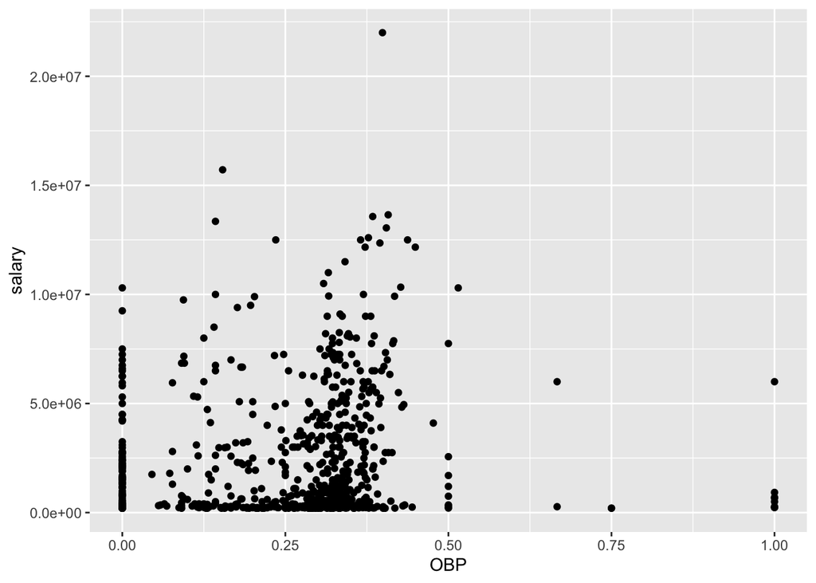

```r
ggplot(available_players,aes(x=OBP,y=salary)) + geom_point()
```

```r
available_players <- filter(available_players,salary<8000000,OBP>0) #no point in having players with too large of a salary and 0

#have greater at bats for lost players
totalatbats <- sum(lost_players$AB)
totalatbats #1469 rougle around 500 each, so players should have at least that
```

```
## [1] 1469
```

```r
available_players <- filter(available_players, AB >= 500)

#sort by OBP
possiblepicks <- arrange(available_players, desc(OBP))
head(possiblepicks, 10)
```

```
##     playerID yearID stint teamID.x lgID.x   G G_batting  AB   R   H X2B X3B HR
## 1  giambja01   2001     1      OAK     AL 154       154 520 109 178  47   2 38
## 2  heltoto01   2001     1      COL     NL 159       159 587 132 197  54   2 49
## 3  berkmla01   2001     1      HOU     NL 156       156 577 110 191  55   5 34
## 4  gonzalu01   2001     1      ARI     NL 162       162 609 128 198  36   7 57
## 5  thomeji01   2001     1      CLE     AL 156       156 526 101 153  26   1 49
## 6  alomaro01   2001     1      CLE     AL 157       157 575 113 193  34  12 20
## 7  edmonji01   2001     1      SLN     NL 150       150 500  95 152  38   1 30
## 8  gilesbr02   2001     1      PIT     NL 160       160 576 116 178  37   7 37
## 9  pujolal01   2001     1      SLN     NL 161       161 590 112 194  47   4 37
## 10 olerujo01   2001     1      SEA     AL 159       159 572  91 173  32   1 21
##    RBI SB CS  BB  SO IBB HBP SH SF GIDP G_old        BA       OBP X1B       SLG
## 1  120  2  0 129  83  24  13  0  9   17   154 0.3423077 0.4769001  91 0.6596154
## 2  146  7  5  98 104  15   5  1  5   14   159 0.3356048 0.4316547  92 0.6848382
## 3  126  7  9  92 121   5  13  0  6    8   156 0.3310225 0.4302326  97 0.6204506
```

[output cut: 18 more lines]

```r
possible <- possiblepicks[2:4,] #because cant pick giambja01 again (who's in first on our list)
possible
```

```
##    playerID yearID stint teamID.x lgID.x   G G_batting  AB   R   H X2B X3B HR
## 2 heltoto01   2001     1      COL     NL 159       159 587 132 197  54   2 49
## 3 berkmla01   2001     1      HOU     NL 156       156 577 110 191  55   5 34
## 4 gonzalu01   2001     1      ARI     NL 162       162 609 128 198  36   7 57
##   RBI SB CS  BB  SO IBB HBP SH SF GIDP G_old        BA       OBP X1B       SLG
## 2 146  7  5  98 104  15   5  1  5   14   159 0.3356048 0.4316547  92 0.6848382
## 3 126  7  9  92 121   5  13  0  6    8   156 0.3310225 0.4302326  97 0.6204506
## 4 142  1  1 100  83  24  14  0  5   14   162 0.3251232 0.4285714  98 0.6880131
##   teamID.y lgID.y  salary
## 2      COL     NL 4950000
## 3      HOU     NL  305000
## 4      ARI     NL 4833333
```

```r
#check if their mean OBP is greater than 0.3638687
possiblemeanOBP <- mean(possible$OBP)
possiblemeanOBP #yes
```

```
## [1] 0.4301529
```

```r
#check if their salary doesn't exceed 15 million
sum(possible$salary) #yes
```

```
## [1] 10088333
```

```r
#check if their combined AB greater than lost players (1469)
sum(possible$AB) #yes
```

```
## [1] 1773
```

## Results

3 new players: heltoto01, berkmla01, gonzalu01